# Buyout Policy

Ernesto

June 14, 2017

# Buyout Narrative

Here’s a very simple update on the [narrative demos](http://carrknight.github.io/poseidon/narrative.html).  
One key result there is that with no policy we get biomass collapse within 10 years or so. In the previous demos we tried to fix this with quotas (tradeable or non-tradeable), protected areas and so on.

In this demo we try a much simpler policy. We try to “buy out” as many large boats as needed to maximize profits over the long run (30 years). First we can study in isolation what happens if we could reduce the number of big boats in the sea costlessly:

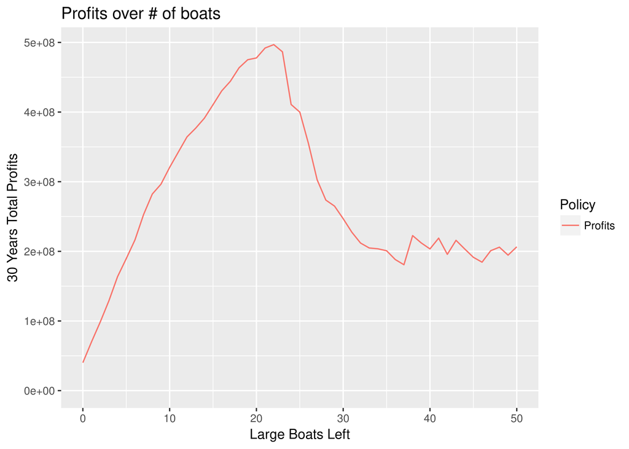

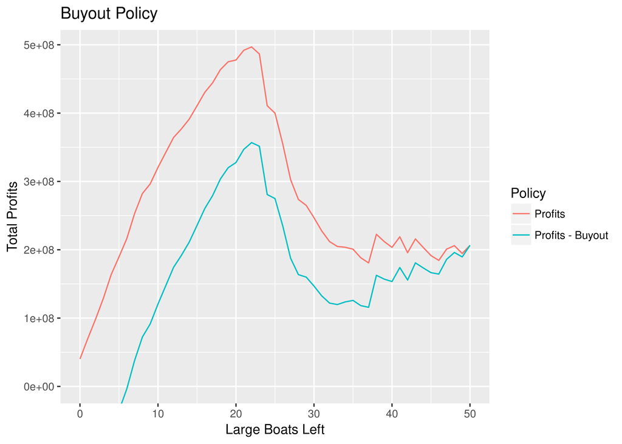

The blue line shows the overall new benefit. As you can see, the peak is almost unchanged (optimal results happen at 22 boats) but the graph also shows that the buyback needs to be consistent before we see any result: the total benefits of leaving 30 boats are lower than taking no boats out once we factor in the buy-back costs.

We can of course still think in terms of large-small boats subdivision of income. Buyback itself doesn’t really address that directly (even a few large boats can kill off the near-shore fishery). We can see this by subdividing overall profits made between large and small boats and we see how the great majority of income is still allocated to the large boats remaining.

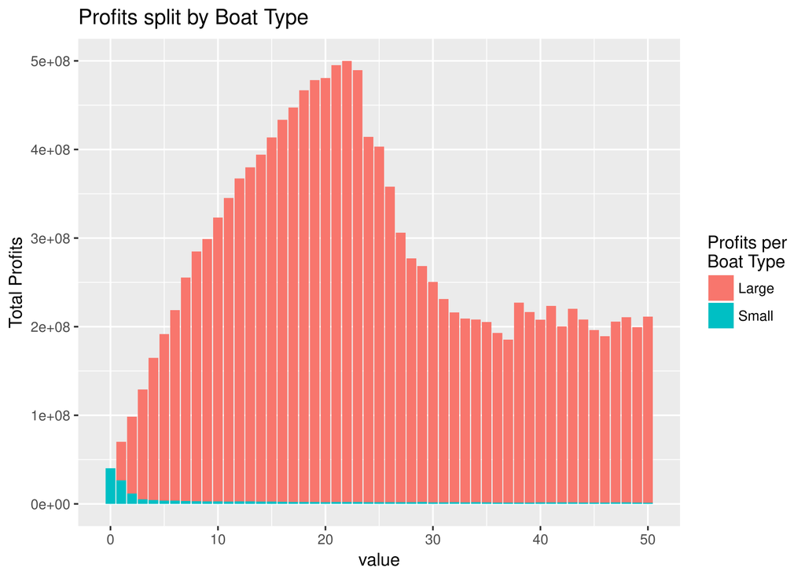